# Course Project Machine Learning

Cindy Lubbers-Benning

Sunday, January 18, 2015

# Summary

We had to prepare the data before we could use it. We trained a random forest model and used cross validation to estimate the out-of-sample accuracy and pick the model with the highest out-of-sample accuracy.The true out-of-sample accuracy (unbiased) was, calculated on an until then unused test set, 0.9983431

# Analysis

First read in the train data (the test data contains 20 cases for the programming assignment)

```r
data <- read.csv('pml-training.csv')
```

Split the data into a training and testing set

```r
#set a seed to produce the same results over and over again
set.seed(998)
library(caret)
inTrain <- createDataPartition(y=data$classe,
                              p=0.6, list=FALSE)
training <- data[inTrain,]
testing <- data[-inTrain,]
```

Look at the data by using the summary function (do not use the testing set!)

```r
summary(training)
```

```
##        X            user_name    raw_timestamp_part_1 raw_timestamp_part_2
##  Min.   :    1   adelmo  :2384   Min.   :1.322e+09    Min.   :   294
##  1st Qu.: 4910   carlitos:1876   1st Qu.:1.323e+09    1st Qu.:252510
##  Median : 9792   charles :2122   Median :1.323e+09    Median :492417
##  Mean   : 9811   eurico  :1823   Mean   :1.323e+09    Mean   :499068
##  3rd Qu.:14768   jeremy  :2021   3rd Qu.:1.323e+09    3rd Qu.:750625
##  Max.   :19622   pedro   :1550   Max.   :1.323e+09    Max.   :998750
##
##           cvtd_timestamp new_window    num_window      roll_belt
##  05/12/2011 11:24: 931   no :11540   Min.   :  1.0   Min.   :-28.90
##  28/11/2011 14:14: 887   yes:  236   1st Qu.:221.0   1st Qu.:  1.10
##  30/11/2011 17:11: 844               Median :424.0   Median :114.00
##  02/12/2011 14:57: 840               Mean   :430.7   Mean   : 64.69
##  02/12/2011 13:34: 835               3rd Qu.:643.0   3rd Qu.:123.00
##  05/12/2011 11:25: 827               Max.   :864.0   Max.   :162.00
##  (Other)         :6612
##    pitch_belt          yaw_belt       total_accel_belt kurtosis_roll_belt
##  Min.   :-55.8000   Min.   :-180.00   Min.   : 0.00             :11540
##  1st Qu.:  1.4600   1st Qu.: -88.20   1st Qu.: 3.00    #DIV/0!  :    3
##  Median :  5.2800   Median : -12.45   Median :17.00    -1.908453:    2
##  Mean   :  0.1108   Mean   : -10.43   Mean   :11.35    -0.021024:    1
##  3rd Qu.: 15.0000   3rd Qu.:  14.00   3rd Qu.:18.00    -0.025513:    1
##  Max.   : 60.3000   Max.   : 179.00   Max.   :28.00    -0.033935:    1
##                                                        (Other)  :  228
##  kurtosis_picth_belt kurtosis_yaw_belt skewness_roll_belt
##           :11540            :11540              :11540
##  #DIV/0!  :   20     #DIV/0!:  236     #DIV/0!  :    2
##  -0.150950:    3                       0.000000 :    2
##  -2.060105:    3                       0.422463 :    2
##  -0.758615:    2                       -0.010002:    1
##  -1.122700:    2                       -0.014020:    1
##  (Other)  :  206                       (Other)  :  228
##  skewness_roll_belt.1 skewness_yaw_belt max_roll_belt     max_picth_belt
##           :11540             :11540     Min.   :-94.300   Min.   : 3.00
##  #DIV/0!  :   20      #DIV/0!:  236     1st Qu.:-88.000   1st Qu.: 5.00
##  -0.189082:    2                        Median : -5.600   Median :18.00
##  -1.362688:    2                        Mean   : -8.868   Mean   :12.89
##  -2.816699:    2                        3rd Qu.: 14.950   3rd Qu.:19.00
##  -3.777024:    2                        Max.   :180.000   Max.   :30.00
##  (Other)  :  208                        NA's   :11540     NA's   :11540
```

[output cut: 305 more lines]

```
##  Min.   :-8.0900   Min.   :-498.00   Min.   :-632.0   Min.   :-391.00
##  1st Qu.:-0.1800   1st Qu.:-177.00   1st Qu.:  60.0   1st Qu.:-181.00
##  Median : 0.0800   Median : -56.00   Median : 201.0   Median : -39.00
##  Mean   : 0.1417   Mean   : -61.05   Mean   : 164.8   Mean   : -55.22
##  3rd Qu.: 0.4900   3rd Qu.:  78.00   3rd Qu.: 314.0   3rd Qu.:  26.00
##  Max.   : 4.1000   Max.   : 477.00   Max.   : 591.0   Max.   : 291.00
##
##  magnet_forearm_x  magnet_forearm_y magnet_forearm_z classe
##  Min.   :-1280.0   Min.   :-896.0   Min.   :-973.0   A:3348
##  1st Qu.: -614.0   1st Qu.:   2.0   1st Qu.: 191.8   B:2279
##  Median : -371.0   Median : 595.0   Median : 512.0   C:2054
##  Mean   : -309.1   Mean   : 381.7   Mean   : 395.2   D:1930
##  3rd Qu.:  -72.0   3rd Qu.: 738.0   3rd Qu.: 653.0   E:2165
##  Max.   :  672.0   Max.   :1480.0   Max.   :1090.0
##
```

A lot of features only have values if new_window is yes. On top of that there are some divisions by zero. So, many numerical features are interpreted as factor features. And those factor features contain a lot of missings (19216 of 19622, 98% missing). Let’s just skip those features. We also drop the feature new_window.

Also drop X (the first feature), this contains the rownumber. As classe is also ordered by rownumber, this feature will be an almost perfect predictor. Nevertheless, a useless predictor. You never want to use features like rownumber, because they are not generalisable on a new dataset. The next plot shows the dependence.

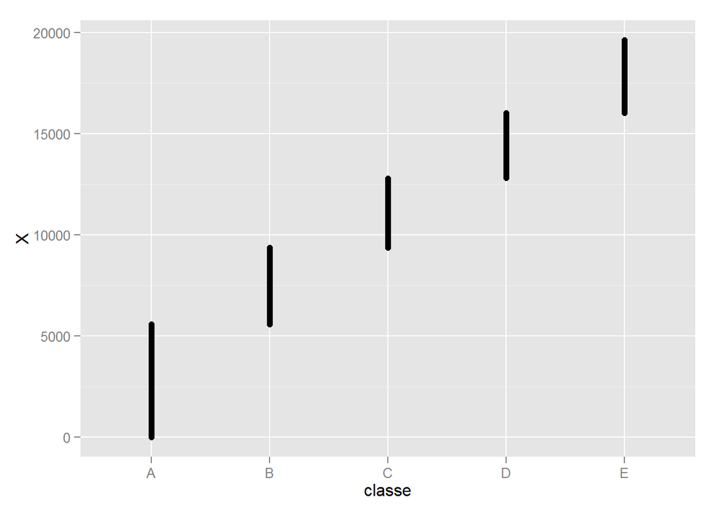

```r
qplot(classe,X, data= training)
```

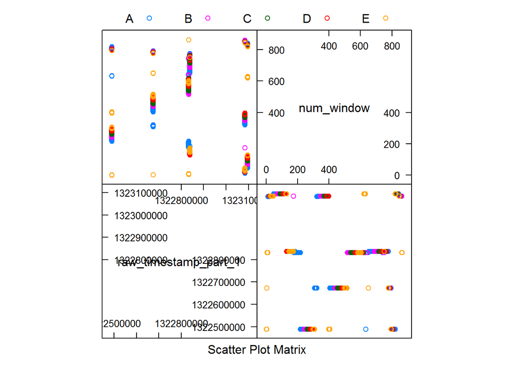

```r
#some more suspicious features
featurePlot(x=training[,c("raw_timestamp_part_1","num_window")],
            y = training$classe,
            plot="pairs",  auto.key = list(columns = 5))
```

```r
#find the factor features
factor_cols <- vapply(training, is.factor, logical(1))
#Create a new dataset "data_new" that doesn't contain the factor features
training_new <- training[,-which(factor_cols)]
training_new <- training_new[,-1]

# Replace the remaining missings using knnImpute
pre_Obj <- preProcess(training_new,method = c("knnImpute") )
training_new_imp <- predict(pre_Obj,training_new)

# Now add the features user_name and Classe again (knnImpute can only handle numerical inputs)
training_new_imp$user_name <- training$user_name
training_new_imp$classe <- training$classe

# The sum of missings shows all missing values are imputed, as we wished
sum(is.na(training_new_imp))
```

```
## [1] 0
```

Build a random forest model on the training data created above. We use cross validation to estimate the out-of-sample accuracy. The default is 10 folds. This means that a model was built on ten sets, every time leaving 10% out. On this 10% the accuracy is being calculated ten times.

```r
#set a seed to produce the same results over and over again
set.seed(666)
rfmodelcv <- train(classe~., data = training_new_imp, method = "rf", trControl = trainControl(method = "cv", number = 10))
rfmodelcv
```

```
## Random Forest
##
## 11776 samples
##   123 predictor
##     5 classes: 'A', 'B', 'C', 'D', 'E'
##
## No pre-processing
## Resampling: Cross-Validated (10 fold)
##
## Summary of sample sizes: 10599, 10599, 10599, 10597, 10599, 10599, ...
##
## Resampling results across tuning parameters:
##
##   mtry  Accuracy   Kappa      Accuracy SD  Kappa SD
##     2   0.9796195  0.9742130  0.003837957  0.004856578
##    64   0.9967729  0.9959181  0.001253698  0.001585767
##   127   0.9954138  0.9941988  0.001887658  0.002387980
##
## Accuracy was used to select the optimal model using  the largest value.
## The final value used for the model was mtry = 64.
```

```r
#Look at the most important features for the model
varImp(rfmodelcv)
```

```
## rf variable importance
##
##   only 20 most important variables shown (out of 127)
##
##                      Overall
## raw_timestamp_part_1 100.000
## roll_belt             45.783
## num_window            43.480
## amplitude_yaw_arm     21.686
## magnet_dumbbell_z     20.446
## yaw_belt              20.087
## pitch_belt            15.223
## magnet_dumbbell_y     13.642
## pitch_forearm         11.639
## roll_dumbbell          9.453
## roll_forearm           9.427
## magnet_dumbbell_x      7.547
## accel_dumbbell_y       5.802
## accel_belt_z           4.941
## accel_dumbbell_z       4.894
## magnet_belt_y          4.716
## accel_forearm_x        3.918
## total_accel_dumbbell   3.800
## magnet_belt_z          3.723
## yaw_dumbbell           3.590
```

The average out-of-sample accuracy in the cross validation is reported, namely 0.9967729. This accuracy might be a bit biased, bacause this accuracy was used for model selection (model picked with highest out-of-sample accuracy).

```r
testing_new <- testing[,-which(factor_cols)]
testing_new <- testing_new[,-1]

testing_new_imp <- predict(pre_Obj,testing_new)

# Now add the features user_name and Classe again (knnImpute can only handle numerical inputs)
testing_new_imp$user_name <- testing$user_name
testing_new_imp$classe <- testing$classe

testingpred <- predict(rfmodelcv, newdata=testing_new_imp)

conf <- confusionMatrix(testingpred, testing_new_imp$classe )
conf
```

```
## Confusion Matrix and Statistics
##
##           Reference
## Prediction    A    B    C    D    E
##          A 2230    0    0    0    0
##          B    2 1517    3    0    0
##          C    0    1 1364    2    0
##          D    0    0    1 1284    4
##          E    0    0    0    0 1438
##
## Overall Statistics
##
##                Accuracy : 0.9983
##                  95% CI : (0.9972, 0.9991)
##     No Information Rate : 0.2845
##     P-Value [Acc > NIR] : < 2.2e-16
##
##                   Kappa : 0.9979
##  Mcnemar's Test P-Value : NA
##
## Statistics by Class:
##
##                      Class: A Class: B Class: C Class: D Class: E
## Sensitivity            0.9991   0.9993   0.9971   0.9984   0.9972
## Specificity            1.0000   0.9992   0.9995   0.9992   1.0000
## Pos Pred Value         1.0000   0.9967   0.9978   0.9961   1.0000
## Neg Pred Value         0.9996   0.9998   0.9994   0.9997   0.9994
## Prevalence             0.2845   0.1935   0.1744   0.1639   0.1838
## Detection Rate         0.2842   0.1933   0.1738   0.1637   0.1833
## Detection Prevalence   0.2842   0.1940   0.1742   0.1643   0.1833
## Balanced Accuracy      0.9996   0.9993   0.9983   0.9988   0.9986
```

Therefore we will calculate the true out-of-sample accuracy on the testing set, which is 0.9983431. This value is actually very high, so a very good model has been built. We have therefore no reason to assume we dropped too many features. The model generalises very well on the independent test set. This model also predicts the 20 test cases correctly.

Of course, the out-of-sample accuracy on the testing set is higher than the out-of-sample cross-validated accuracy on the training set. The test set is only one set, with the cross-validation an average of the out-of-sample accuracy is calculated. So this is probably due to coincidence. Nevertheless, the fact remains we built a very good model!